# #Mimulus Genetic Mapping - A new approach with more molecular markers

```r
LG10_final
```

```
##
## Printing map:
##
## Markers               Position
##
##  26 BA449                 0.00
## 250 CC61                  5.09
## 278 MgSTS93              12.20
## 270 MgSTS26              13.39
## 404 MgSTS598             17.78
## 338 MgSTS344             20.19
##
##  6 markers            log-likelihood: -590.8984
```

##########################LG11#################################

```r
LG11_ord <- order_seq(input.seq = LG11, n.init = 7,
                        subset.search = "twopt",
                        twopt.alg = "rcd", THRES = 3)
```

```
##
## Cross type:  f2
## Choosing initial subset using 'two-point' approach
##
## order obtained using RCD algorithm:
##
##  66 101 114 392 298 78 154 201 331 314 183 185 44 189 158 300 144 198 194 205 203 248 30 242
##
## calculating multipoint map using tol =  0.1 .
##
## WARNING: this operation may take a VERY long time
##
## Comparing 2520 orders:
##
##
##
##
##
## Running try algorithm
## 154 --> AA296C    : ........
## 158 --> BA245C    : .........
## 392 --> MgSTS438  : ..........
## 183 --> AAT308    : ..........
## 314 --> MgSTS113  : ...........
##  78 --> CA378     : ...........
## 101 --> CA140     : ...........
## 144 --> BD143     : ...........
## 189 --> BC546     : ...........
## 194 --> BC478     : ............
## 198 --> BC376     : ............
## 203 --> BC266     : ............
## 248 --> CC114     : .............
## 114 --> CB216     : .............
##  30 --> BA394     : ..............
##  44 --> BA175     : ..............
## 201 --> BC330     : ..............
##
## LOD threshold = 3
##
## Positioned markers: 66 114 298 154 201 331 185 183 242 203 300 158 189 205
```

[output cut: 15 more lines]

```
##
##
## Placing remaining marker(s) at most likely position
##  30 --> BA394     : ...............
## 198 --> BC376     : ................
## 248 --> CC114     : .................
## 144 --> BD143     : ..................
## 314 --> MgSTS113  : ...................
##  78 --> CA378     : ....................
## 194 --> BC478     : .....................
## 392 --> MgSTS438  : ......................
##  44 --> BA175     : .......................
## 101 --> CA140     : ........................
##
## Estimating final genetic map using tol = 10E-5.
```

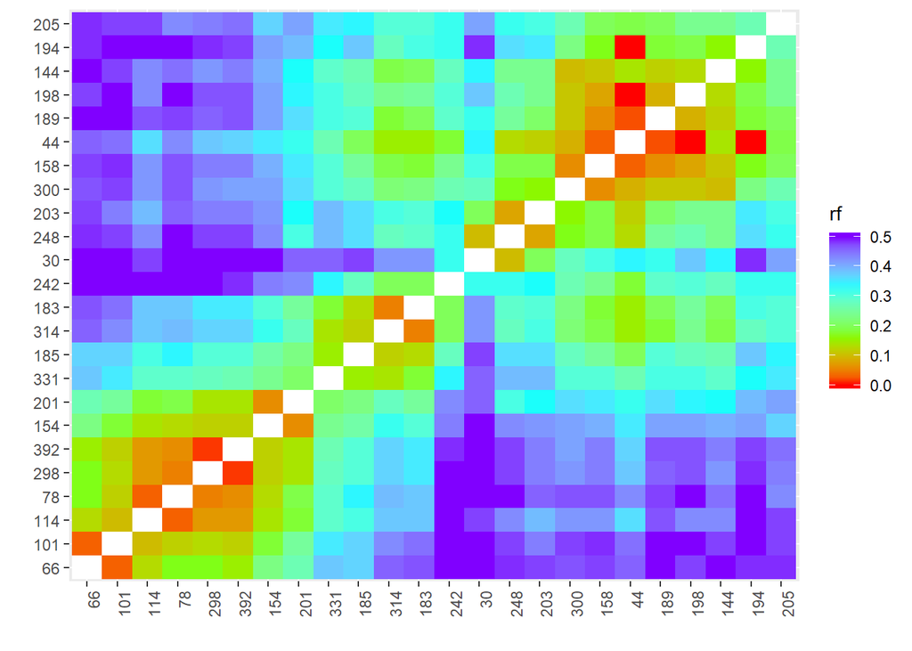

```r
LG11_ORD_all<- make_seq(LG11_ord, "force")
LG11_final<-make_seq(LG11_ord, "safe")
rf_graph_table(LG11_ORD_all)
```

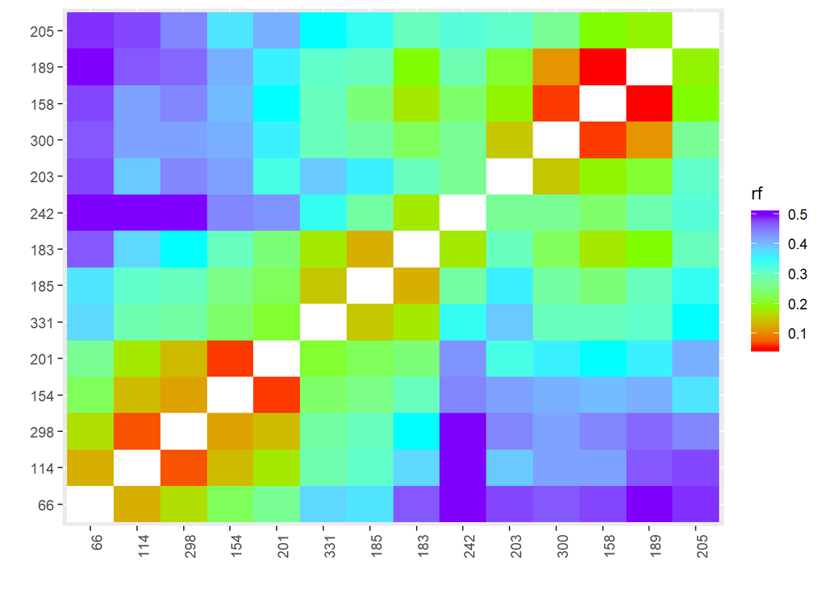

```r
rf_graph_table(LG11_final)
```

```r
LG11_final
```

```
##
## Printing map:
##
## Markers                Position
##
##  66 BB182                  0.00
## 114 CB216                 13.34
## 298 MgSTS36               20.68
## 154 AA296C                33.01
## 201 BC330                 38.96
## 331 MgSTS282B             61.59
## 185 AAT364                77.22
## 183 AAT308                90.21
## 242 CC149                109.53
## 203 BC266                139.46
## 300 MgSTS437             154.46
## 158 BA245C               160.81
## 189 BC546                166.22
## 205 BC219                186.58
##
##  14 markers            log-likelihood: -2014.224
```

##########################LG12#################################

```r
LG12_ord <- order_seq(input.seq = LG12, n.init = 7,
                        subset.search = "twopt",
                        twopt.alg = "rcd", THRES = 3)
```

```
##
## Cross type:  f2
## Choosing initial subset using 'two-point' approach
##
## order obtained using RCD algorithm:
##
##  117 35 390 284 285 407 416 123 79 164 281 121 170 410 207 63 383 304 330 48 241
##
## calculating multipoint map using tol =  0.1 .
##
## WARNING: this operation may take a VERY long time
##
## Comparing 2520 orders:
##
##
##
##
##
## Running try algorithm
## 170 --> AAT240    : ........
## 164 --> CB263C    : .........
## 390 --> MgSTS577  : ..........
## 383 --> MgSTS419  : ..........
## 416 --> MgSTS599  : ..........
## 285 --> MgSTS11   : ...........
## 330 --> MgSTS326  : ...........
## 407 --> MgSTS104  : ............
##  63 --> BB198     : .............
##  48 --> BA145     : ..............
## 207 --> BC199     : ..............
## 121 --> CB126     : ...............
##  79 --> CA315     : ................
##  35 --> BA334     : ................
##
## LOD threshold = 3
##
## Positioned markers: 117 35 284 407 416 123 164 281 121 170 410 330 304 63 207 241
##
## Markers not placed on the map: 48 79 285 383 390
##
##
## Calculating LOD-Scores
##  48 --> BA145     : .................
##  79 --> CA315     : .................
## 285 --> MgSTS11   : .................
## 383 --> MgSTS419  : .................
## 390 --> MgSTS577  : .................
##
##
## Placing remaining marker(s) at most likely position
## 390 --> MgSTS577  : .................
## 285 --> MgSTS11   : ..................
## 383 --> MgSTS419  : ...................
##  79 --> CA315     : ....................
##  48 --> BA145     : .....................
##
## Estimating final genetic map using tol = 10E-5.
```

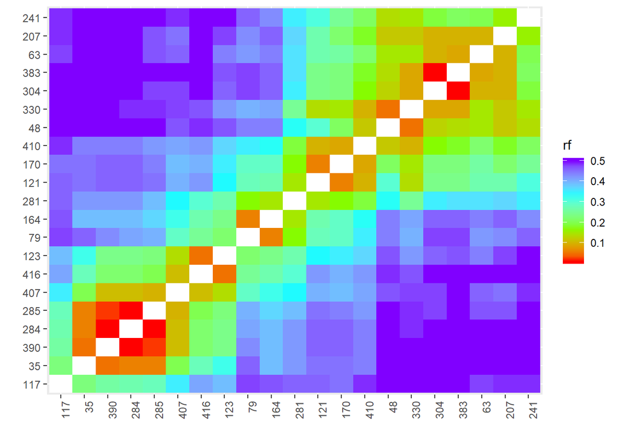

```r
LG12_ORD_all<- make_seq(LG12_ord, "force")
LG12_final<-make_seq(LG12_ord, "safe")
rf_graph_table(LG12_ORD_all)
```

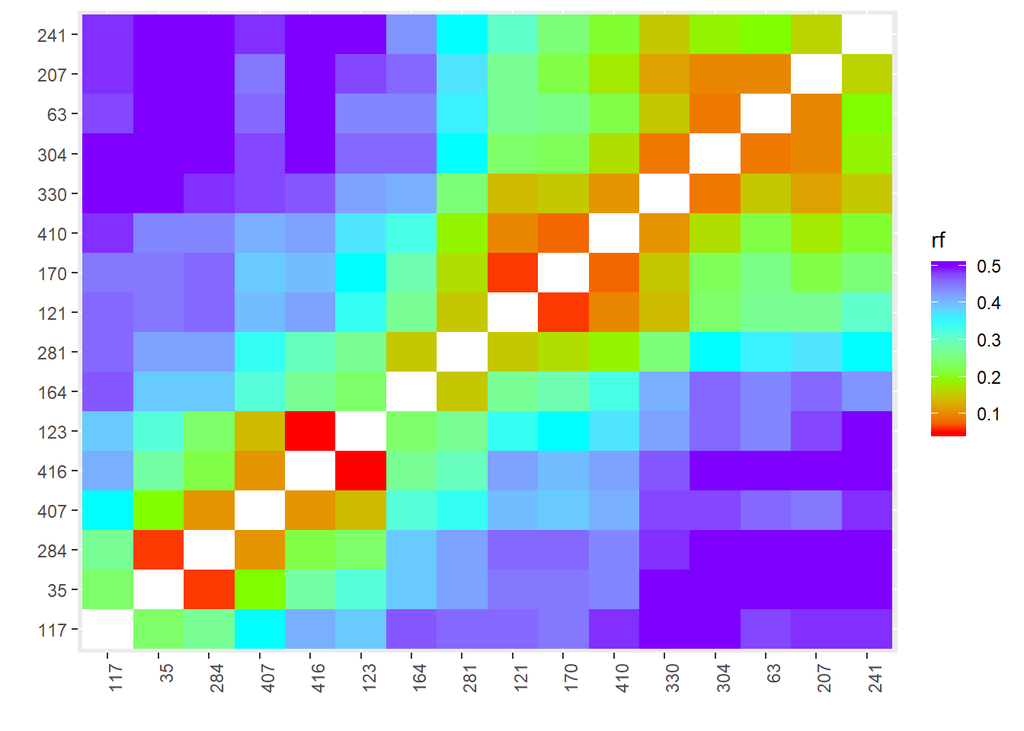

```r
rf_graph_table(LG12_final)
```

```r
LG12_final
```

```
##
## Printing map:
##
## Markers               Position
##
## 117 CB172                 0.00
##  35 BA334                26.12
## 284 MgSTS45              32.05
## 407 MgSTS104             43.63
## 416 MgSTS599             54.93
## 123 CB55                 59.78
## 164 CB263C               86.09
## 281 MgSTS55             101.07
## 121 CB126               116.28
## 170 AAT240              122.04
## 410 MgSTS622            130.58
## 330 MgSTS326            141.69
## 304 MgSTS68             150.93
##  63 BB198               160.48
## 207 BC199               170.96
## 241 CC150               187.17
##
##  16 markers            log-likelihood: -2203.92
```

##########################LG13#################################

```r
LG13_ord <- order_seq(input.seq = LG13, n.init = 7,
                        subset.search = "twopt",
                        twopt.alg = "rcd", THRES = 3)
```

```
##    Length of sequence  LG13  is less than n.init
##    Returning the best order using compare function:
## WARNING: this operation may take a VERY long time
##
## Comparing 360 orders:
##
##
```

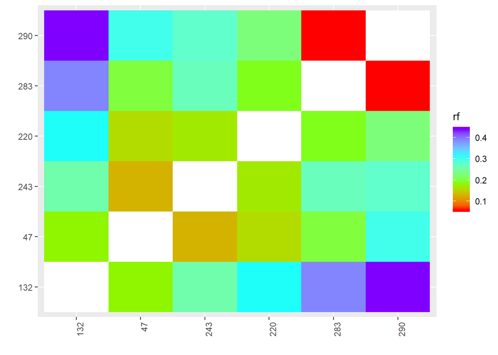

```r
LG13_final<- make_seq(LG13_ord, "force")
LG13_safe<-make_seq(LG13_ord, "safe")
rf_graph_table(LG13_final)
```

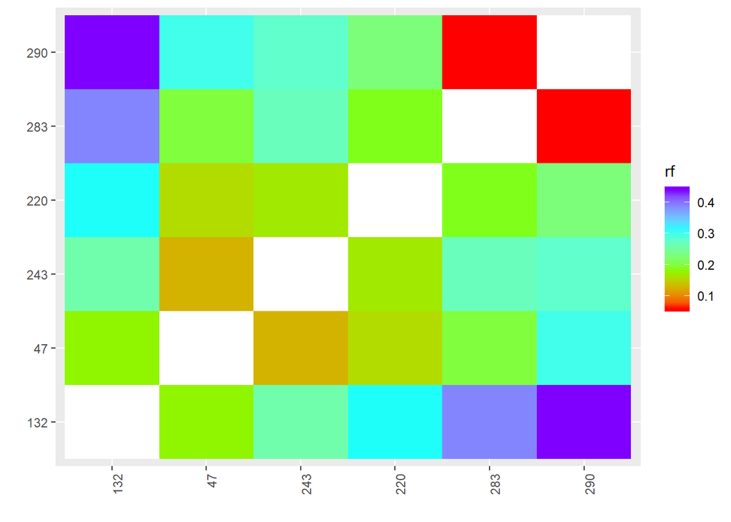

```r
rf_graph_table(LG13_safe)
```

```r
LG13_final
```

```
##
## Printing map:
##
## Markers               Position
##
## 132 BD270                 0.00
##  47 BA153                18.58
## 243 CC138                31.63
## 220 BC194C               48.97
## 283 MgSTS98              69.52
## 290 MgSTS212             75.25
##
##  6 markers            log-likelihood: -858.6445
```

##########################LG14#################################

```r
LG14_ord <- order_seq(input.seq = LG14, n.init = 7,
                        subset.search = "twopt",
                        twopt.alg = "rcd", THRES = 3)
```

```
##    Length of sequence  LG14  is less than n.init
##    Returning the best order using compare function:
##
## Comparing 3 orders:
##
##
```

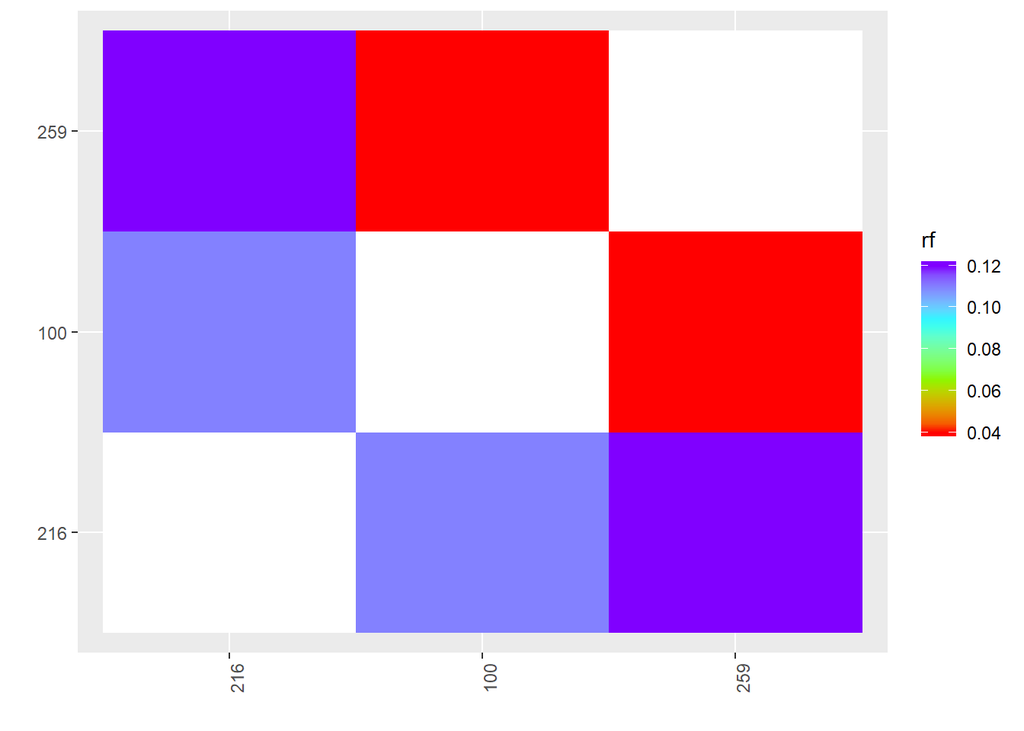

```r
LG14_final<- make_seq(LG14_ord, "force")
LG14_safe<-make_seq(LG14_ord, "safe")
rf_graph_table(LG14_final)
```

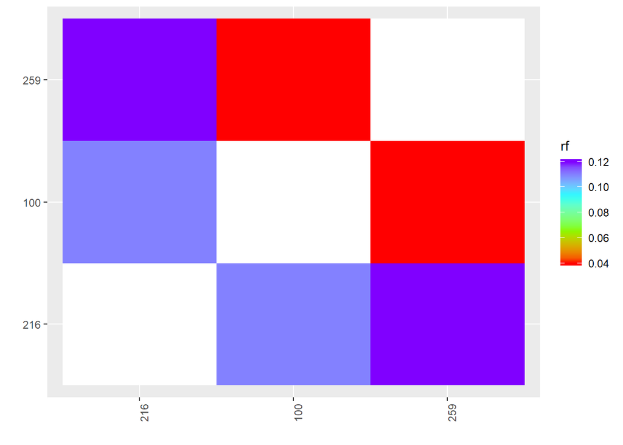

```r
rf_graph_table(LG14_safe)
```

```r
LG14_final
```

```
##
## Printing map:
##
## Markers            Position
##
## 216 BC80               0.00
## 100 CA150             10.74
## 259 AP3               14.70
##
##  3 markers            log-likelihood: -396.303
```

## We have a total of 16 groups

## Looking at the map already published group 1 corresponds to 1 and 13 of our data set

## In the published map group 14 corresponds to the union of groups 9 and 14 of our group.

## However, when we ask for the formation of the groups without the marks removed for the break of group 3 (below), we have the formation of 16 groups, which are the original 14 + 2 originated from the break of group 3 (lod tested 5 8)

## In this way we decided to add tags with segregation detours to increase the size of groups 13 and 14 so that they can be correctly attached to their link groups

```r
marknew <-make_seq(twopts_f2, no_dist)

linkgroups<- drop_marker(marknew,c(92,168,200,405,221,72,235,322,319,356,313,131,184,64,25,228,179,386,237,413,105,3,372,231))

newGroups<-group(linkgroups, LOD = LOD_sug)
```

```
##    Selecting markers:
##    group    1
##     .......
##    group    2
##     ......................
##    group    3
##     .......................................
##    group    4
##     ...............
##    group    5
##     ...................................................
##    group    6
##     ...............
##    group    7
##     ................................
##    group    8
##     ..........................
##    group    9
##     ............
##    group    10
##     ...............................
##    group    11
##     ......
##    group    12
##     ........................
##    group    13
##     ..............
##    group    14
##     .....................
##    group    15
##     ......
##    group    16
##     ...
```

```r
maps_list <- list(LG1_final, LG2_final, LG3.1_final,LG3.2_final,LG3.3_final,LG4_final,LG5_final,LG6_final,LG7_final,LG8_final,LG9_final,LG10_final,LG11_final,LG12_final,LG13_final,LG14_final)
```

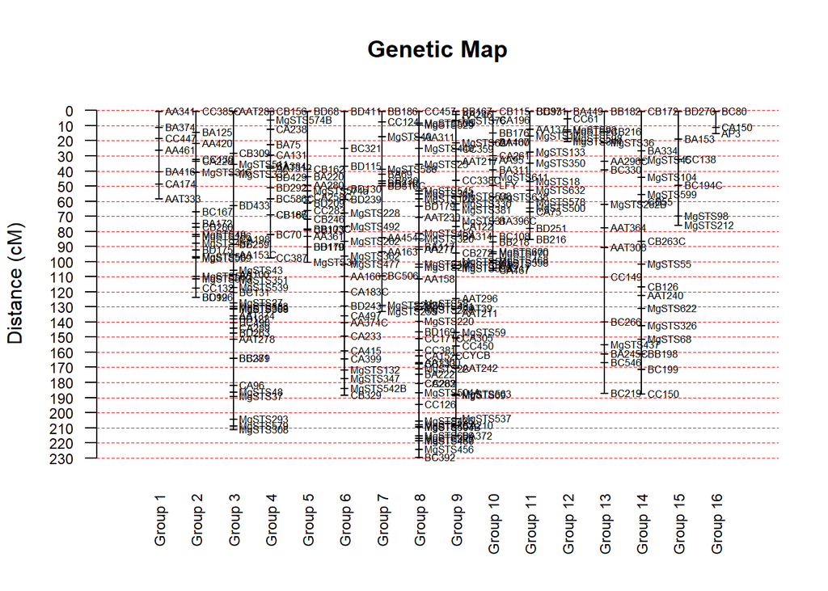

```r
draw_map(maps_list, names = TRUE, grid = TRUE, cex.mrk = 0.7)
```

```r
dist <- select_segreg(f2_test, distorted = TRUE, numbers = TRUE)
dist
```

```
##  [1]  16  31  41  43  49  55  69  85  86  91 128 136 141 147 152 163 167
## [18] 169 176 177 178 182 196 219 234 236 251 261 263 265 266 275 276 277
## [35] 286 287 288 294 305 307 308 320 323 325 328 335 337 339 346 353 355
## [52] 361 370 377 379 380 382 391 393 394 396 406
```

```r
mark_dist <- make_seq(twopts_f2, dist)
mark_dist[["seq.num"]]
```

```
##  [1]  16  31  41  43  49  55  69  85  86  91 128 136 141 147 152 163 167
## [18] 169 176 177 178 182 196 219 234 236 251 261 263 265 266 275 276 277
## [35] 286 287 288 294 305 307 308 320 323 325 328 335 337 339 346 353 355
## [52] 361 370 377 379 380 382 391 393 394 396 406
```

```r
# Using markers with segregation distortion
```

```r
mark_dist <- add_marker(mark_dist, c( 216,100,259,132,47,243,220,283,290))
mark_dist[["seq.num"]]
```

```
##  [1]  16  31  41  43  49  55  69  85  86  91 128 136 141 147 152 163 167
## [18] 169 176 177 178 182 196 219 234 236 251 261 263 265 266 275 276 277
## [35] 286 287 288 294 305 307 308 320 323 325 328 335 337 339 346 353 355
## [52] 361 370 377 379 380 382 391 393 394 396 406 216 100 259 132  47 243
## [69] 220 283 290
```

```r
# adding groups 13 and 14 marks
```

```r
LGdist <- group(mark_dist, LOD = LOD_sug)
```

```
##    Selecting markers:
##    group    1
##     ...........................................
##    group    2
##     ...........
##    group    3
##     .....
##    group    4
##     ....
##    group    5
##     ...
```

```r
LGdist
```

```
##   This is an object of class 'group'
##   It was generated from the object "mark_dist"
##
##   Criteria used to assign markers to groups:
##     LOD = 5.429707 , Maximum recombination fraction = 0.5
##
##   No. markers:            71
##   No. groups:             5
##   No. linked markers:     66
##   No. unlinked markers:   5
##
##   Printing groups:
##   Group 1 : 43 markers
##     AA173C BA387 BA214 BA196 BA129 BB124 BD340 BD100 CA389C AAT225 AAT267 BC526C CC320 CC53 MgSTS20 MgSTS19 MgSTS24 MgSTS29 MgSTS91 CYCA aat356 MgSTS87 MgSTS520 MgSTS360 MgSTS336 MgSTS358 MgSTS471 MgSTS380 MgSTS263 MgSTS583 MgSTS631 MgSTS561 MgSTS483 MgSTS620 BC80 CA150 AP3 BD270 BA153 CC138 BC19…
##
##   Group 2 : 11 markers
##     CA267 AAT265 MgSTS16 MgSTS38 MgSTS527 MgSTS341 MgSTS348 MgSTS491 MgSTS398 MgSTS562 MgSTS494
##
##   Group 3 : 5 markers
##     CA264 CA226 BD173 CC342 MgSTS245
##
##   Group 4 : 4 markers
##     BD242 AAT272 BC388 MgSTS548
##
##   Group 5 : 3 markers
##     MgSTS70 MgSTS75 MgSTS435
##
##   Unlinked markers: 5  markers
##     BB327 AA118C AAT233 AAT367 MgSTS425
```

```r
# The marks of the two groups have been grouped in group 1, we will now sort the marks
LGfantasma <- make_seq(LGdist, 1)
LGfantas <- order_seq(input.seq = LGfantasma, n.init = 7,
                        subset.search = "twopt",
                        twopt.alg = "rcd", THRES = 3)
```

```
##
## Cross type:  f2
## Choosing initial subset using 'two-point' approach
##
## order obtained using RCD algorithm:
##
##  290 283 167 132 243 220 16 328 47 163 49 41 169 219 277 263 31 265 406 355 320 251 128 69 43 147 380 339 287 286 288 337 361 275 377 308 370 236 266 396 259 100 216
##
## calculating multipoint map using tol =  0.1 .
##
## WARNING: this operation may take a VERY long time
##
## Comparing 2520 orders:
##
##
##
##
##
## Running try algorithm
## 396 --> MgSTS483  : ........
## 163 --> CA389C    : ........
##  16 --> AA173C    : .........
## 370 --> MgSTS583  : ..........
## 377 --> MgSTS631  : ...........
## 169 --> AAT267    : ............
## 380 --> MgSTS561  : .............
## 263 --> MgSTS20   : .............
## 406 --> MgSTS620  : .............
## 288 --> MgSTS87   : ..............
## 283 --> MgSTS98   : ...............
## 265 --> MgSTS19   : ................
## 266 --> MgSTS24   : .................
## 337 --> MgSTS358  : ..................
## 219 --> BC526C    : ...................
## 220 --> BC194C    : ....................
## 167 --> AAT225    : .....................
## 320 --> MgSTS360  : ......................
## 355 --> MgSTS380  : .......................
## 275 --> MgSTS29   : ........................
## 259 --> AP3       : .........................
```

[output cut: 32 more lines]

```
##  47 --> BA153     : ...................................
##
##
## Placing remaining marker(s) at most likely position
## 263 --> MgSTS20   : ...................................
## 380 --> MgSTS561  : ....................................
## 361 --> MgSTS263  : .....................................
## 236 --> CC320     : ......................................
## 396 --> MgSTS483  : .......................................
## 259 --> AP3       : ........................................
##  47 --> BA153     : .........................................
##  43 --> BA196     : ..........................................
## 286 --> CYCA      : ...........................................
##
## Estimating final genetic map using tol = 10E-5.
```

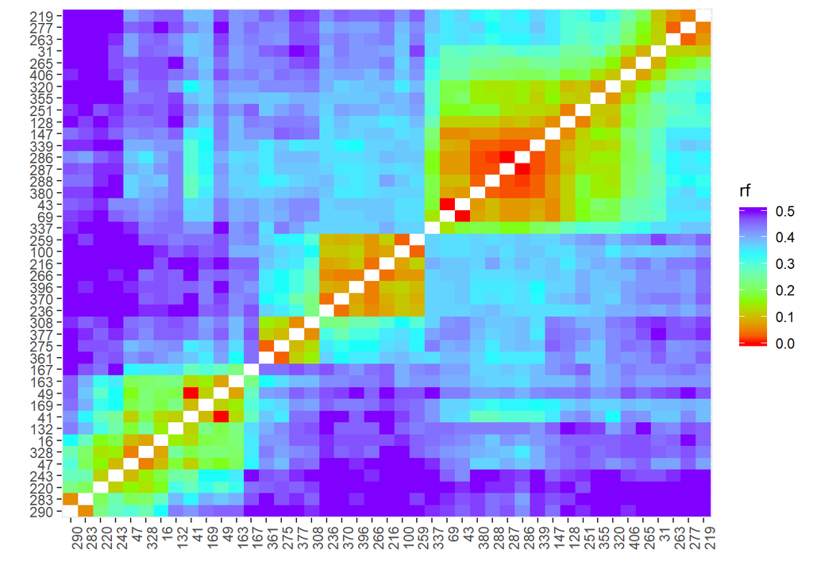

```r
LGfantasmaparc<- make_seq(LGfantas, "force")
rf_graph_table(LGfantasmaparc)
```

```r
LGfantasmaparc
```

```
##
## Printing map:
##
## Markers               Position
##
## 290 MgSTS212              0.00
## 283 MgSTS98               5.73
## 220 BC194C               26.44
## 243 CC138                39.13
##  47 BA153                49.27
## 328 MgSTS336             54.73
##  16 AA173C               62.55
## 132 BD270                78.28
##  41 BA214                90.22
## 169 AAT267              100.21
```

[output cut: 35 more lines]

## We can clearly see 3 distinct groups, group 13, 14 and a new group of markers with distortion o (? Right)

## Does this last match map 11 with map j? published, which corresponds to our group 10.

## At this time, the marks should be removed and later added to our group 10.

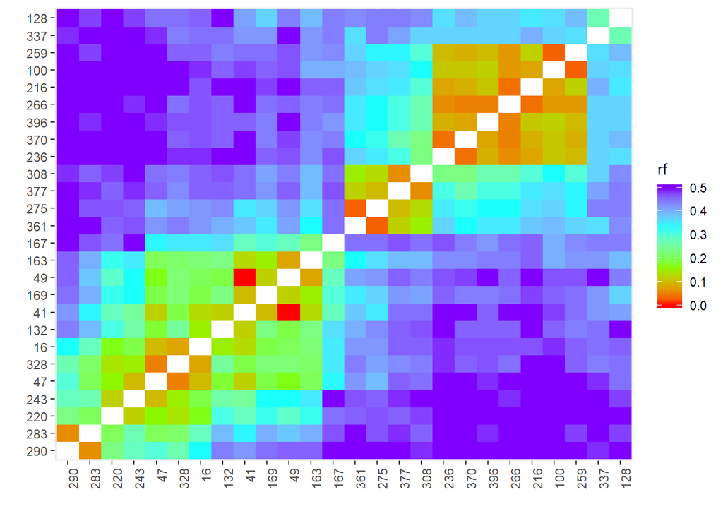

```r
LGfantasmaparc2<-drop_marker(LGfantasmaparc,c(69,43,380,288,287,286,339,147,251,355,320,406,265,31,263,277,219))
LGfantasmaparc2 <- map(LGfantasmaparc2)
rf_graph_table(LGfantasmaparc2)
```

```r
LGfantasmaparc2
```

```
##
## Printing map:
##
## Markers               Position
##
## 290 MgSTS212              0.00
## 283 MgSTS98               5.73
## 220 BC194C               26.44
## 243 CC138                39.13
##  47 BA153                49.27
## 328 MgSTS336             54.73
##  16 AA173C               62.55
## 132 BD270                78.28
##  41 BA214                90.22
## 169 AAT267              100.21
```

[output cut: 18 more lines]

```r
## We now have only two groups, the one of the left corresponding to the old group 13 and the one of the right to the old group 14,

## This time the old group 14 + the new brands be added to group 9 and sorted again (due to the matching of the marks on the original map)
LG9_final <- add_marker(LG9_final,c(361,275,377,308,236,370,396,266,216,100,259))
```

```r
LG9_FINAL2 <- order_seq(input.seq = LG9_final, n.init = 7,
                        subset.search = "twopt",
                        twopt.alg = "rcd", THRES = 3)
```

```
##
## Cross type:  f2
## Choosing initial subset using 'two-point' approach
##
## order obtained using RCD algorithm:
##
##  60 134 105 350 362 385 262 334 279 361 275 249 127 260 21 377 308 370 236 266 396 259 100 216
##
## calculating multipoint map using tol =  0.1 .
##
## WARNING: this operation may take a VERY long time
##
## Comparing 2520 orders:
##
##
##
##
##
## Running try algorithm
## 396 --> MgSTS483  : ........
## 385 --> MgSTS632  : .........
## 370 --> MgSTS583  : ..........
## 260 --> MgSTS17   : ..........
## 262 --> MgSTS18   : ...........
## 308 --> MgSTS520  : ............
## 334 --> MgSTS350  : .............
## 350 --> MgSTS500  : ..............
## 275 --> MgSTS29   : ...............
## 259 --> AP3       : ...............
## 361 --> MgSTS263  : ...............
## 100 --> CA150     : ...............
## 127 --> BD371     : ................
## 134 --> BD251     : ................
## 236 --> CC320     : ................
## 105 --> CA75      : ................
##  21 --> AA137     : .................
##
## LOD threshold = 3
##
## Positioned markers: 60 105 350 362 385 262 334 279 249 21 260 377 308 396 266 216 100
```

[output cut: 9 more lines]

```
## 236 --> CC320     : ..................
## 370 --> MgSTS583  : ..................
## 259 --> AP3       : ..................
##
##
## Placing remaining marker(s) at most likely position
## 370 --> MgSTS583  : ..................
## 275 --> MgSTS29   : ...................
## 236 --> CC320     : ....................
## 361 --> MgSTS263  : .....................
## 259 --> AP3       : ......................
## 127 --> BD371     : .......................
## 134 --> BD251     : ........................
##
## Estimating final genetic map using tol = 10E-5.
```

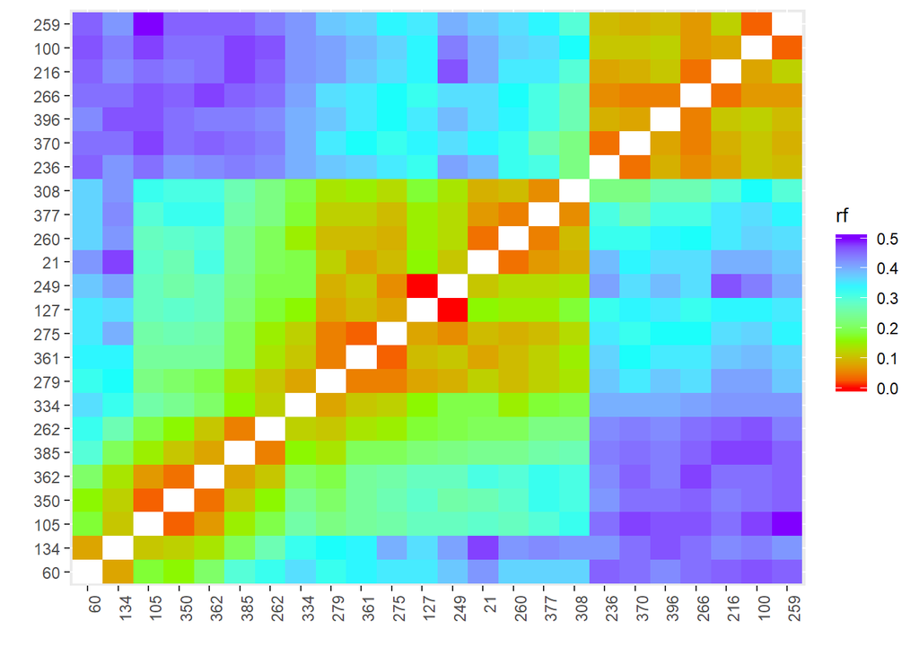

```r
LG9final2<- make_seq(LG9_FINAL2, "force")
rf_graph_table(LG9final2)
```

```r
LG9final2
```

```
##
## Printing map:
##
## Markers               Position
##
##  60 BB216                 0.00
## 134 BD251                 7.73
## 105 CA75                 18.52
## 350 MgSTS500             21.07
## 362 MgSTS578             25.03
## 385 MgSTS632             32.97
## 262 MgSTS18              38.34
## 334 MgSTS350             50.89
## 279 MgSTS133             58.83
## 361 MgSTS263             63.45
```

[output cut: 16 more lines]

```r
# Adicionaremos as marcas do antigo grupo 13 + como novas marcas mapeadas ao grupo 1 (devido a uma correspondÃÂªncia de marcas no mapa original)
LG1_final <- add_marker(LG1_final,c(290,283,220,243,47,328,16,132,41,169,49,163,167))
LG1_FINAL2 <- order_seq(input.seq = LG1_final, n.init = 7,
                        subset.search = "twopt",
                        twopt.alg = "rcd", THRES = 3)
```

```
##
## Cross type:  f2
## Choosing initial subset using 'two-point' approach
##
## order obtained using RCD algorithm:
##
##  167 8 33 1 226 258 28 97 163 49 41 47 328 16 220 243 132 169 283 290
##
## calculating multipoint map using tol =  0.1 .
##
## WARNING: this operation may take a VERY long time
##
## Comparing 2520 orders:
##
##
##
##
##
## Running try algorithm
## 163 --> CA389C    : ........
## 169 --> AAT267    : .........
## 283 --> MgSTS98   : ..........
## 220 --> BC194C    : ...........
## 258 --> AAT333    : ............
## 328 --> MgSTS336  : ............
##  97 --> CA174     : .............
## 226 --> CC447     : ..............
##   8 --> AA341     : ..............
##  33 --> BA374     : ..............
##  47 --> BA153     : ...............
##  41 --> BA214     : ...............
## 243 --> CC138     : ................
##
## LOD threshold = 3
##
## Positioned markers: 167 33 1 28 97 163 49 169 41 132 16 328 243 220 283 290
##
## Markers not placed on the map: 8 226 258 47
##
##
## Calculating LOD-Scores
##   8 --> AA341     : .................
## 226 --> CC447     : .................
## 258 --> AAT333    : .................
##  47 --> BA153     : .................
##
##
## Placing remaining marker(s) at most likely position
## 226 --> CC447     : .................
##  47 --> BA153     : ..................
## 258 --> AAT333    : ...................
##   8 --> AA341     : ....................
##
## Estimating final genetic map using tol = 10E-5.
```

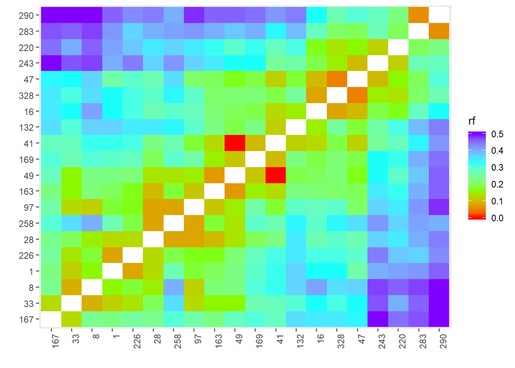

```r
LG1final2<- make_seq(LG1_FINAL2, "force")
rf_graph_table(LG1final2)
```

```r
LG1final2
```

```
##
## Printing map:
##
## Markers               Position
##
## 167 AAT225                0.00
##  33 BA374                12.97
##   8 AA341                22.44
##   1 AA461                39.08
## 226 CC447                46.93
##  28 BA416                60.42
## 258 AAT333               68.82
##  97 CA174                77.09
## 163 CA389C               88.39
##  49 BA129                95.93
## 169 AAT267              107.60
##  41 BA214               117.59
## 132 BD270               129.53
##  16 AA173C              145.26
## 328 MgSTS336            153.08
##  47 BA153               158.54
## 243 CC138               168.68
## 220 BC194C              181.37
## 283 MgSTS98             202.08
## 290 MgSTS212            207.81
##
##  20 markers            log-likelihood: -2594.1
```

# Adicionando marcas com correspondencia do mapa original ao nosso grupo 10.

```r
LG10_final <- add_marker(LG10_final,c(69,43,380,288,287,286,339,147,251,355,320,406,265,31,263,277,219))
LG10_FINAL2 <- order_seq(input.seq = LG10_final, n.init = 7,
                        subset.search = "twopt",
                        twopt.alg = "rcd", THRES = 3)
```

```
##
## Cross type:  f2
## Choosing initial subset using 'two-point' approach
##
## order obtained using RCD algorithm:
##
##  251 69 43 147 380 339 287 286 288 320 355 406 265 31 26 219 250 278 270 404 338 277 263
##
## calculating multipoint map using tol =  0.1 .
##
## WARNING: this operation may take a VERY long time
##
## Comparing 2520 orders:
##
##
##
##
##
## Running try algorithm
## 277 --> MgSTS91   : ........
## 278 --> MgSTS93   : ........
## 288 --> MgSTS87   : ........
## 265 --> MgSTS19   : ........
## 338 --> MgSTS344  : .........
## 404 --> MgSTS598  : ..........
## 320 --> MgSTS360  : ..........
## 355 --> MgSTS380  : ...........
## 287 --> aat356    : ............
## 339 --> MgSTS471  : ............
##  69 --> BB124     : ............
##  26 --> BA449     : ............
##  43 --> BA196     : ............
##  31 --> BA387     : ............
## 147 --> BD100     : .............
## 250 --> CC61      : ..............
##
## LOD threshold = 3
##
## Positioned markers: 380 286 147 251 355 320 406 265 31 250 219 263 270 338
##
```

[output cut: 12 more lines]

```
## 277 --> MgSTS91   : ...............
##
##
## Placing remaining marker(s) at most likely position
## 278 --> MgSTS93   : ...............
## 404 --> MgSTS598  : ................
##  26 --> BA449     : .................
## 277 --> MgSTS91   : ..................
## 288 --> MgSTS87   : ...................
##  43 --> BA196     : ....................
##  69 --> BB124     : .....................
## 339 --> MgSTS471  : ......................
## 287 --> aat356    : .......................
##
## Estimating final genetic map using tol = 10E-5.
```

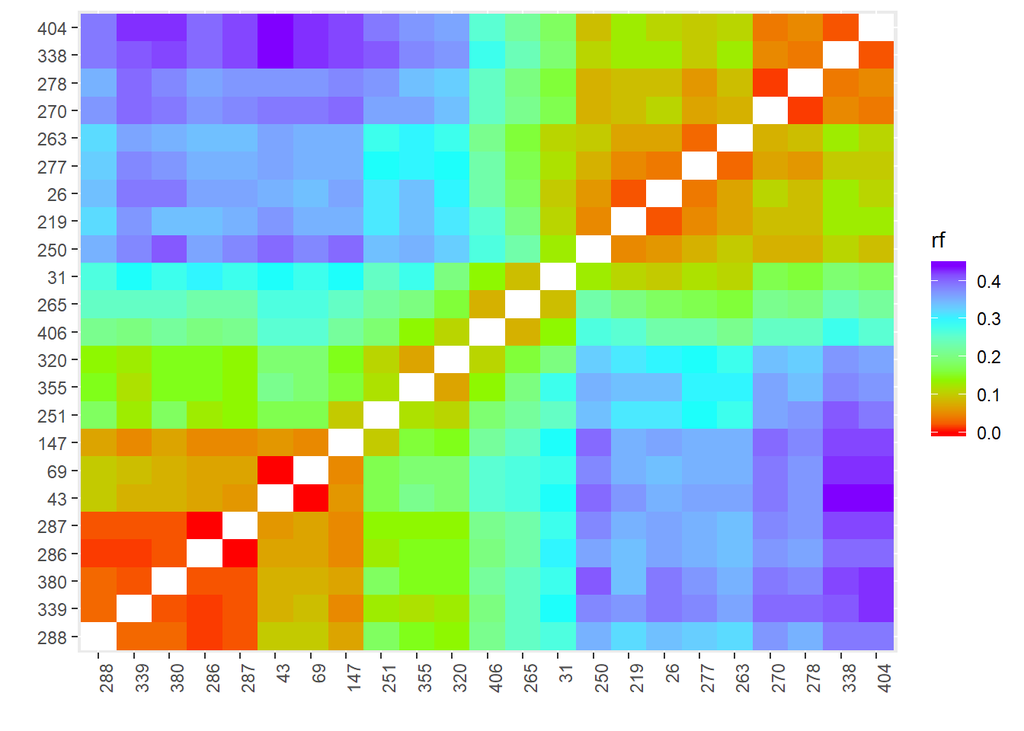

```r
LG10final2<- make_seq(LG10_FINAL2, "force")
rf_graph_table(LG10final2)
```

```r
LG10final2
```

```
##
## Printing map:
##
## Markers               Position
##
## 288 MgSTS87               0.00
## 339 MgSTS471              2.54
## 380 MgSTS561              4.11
## 286 CYCA                  5.75
## 287 aat356                5.75
##  43 BA196                12.16
##  69 BB124                12.16
## 147 BD100                17.42
## 251 CC53                 27.18
## 355 MgSTS380             39.00
## 320 MgSTS360             45.80
## 406 MgSTS620             56.99
## 265 MgSTS19              64.88
##  31 BA387                74.06
## 250 CC61                 87.19
## 219 BC526C               91.73
##  26 BA449                93.61
## 277 MgSTS91              98.00
## 263 MgSTS20             100.94
## 270 MgSTS26             108.58
## 278 MgSTS93             109.87
## 338 MgSTS344            114.01
## 404 MgSTS598            116.02
##
##  23 markers            log-likelihood: -2132.254
```

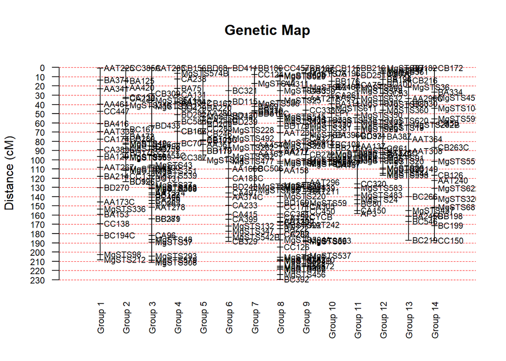

```r
maps_list2 <- list(LG1final2, LG2_final, LG3.1_final,LG3.2_final,LG3.3_final,LG4_final,LG5_final,LG6_final,LG7_final,LG8_final,LG9final2,LG10final2,LG11_final,LG12_final)


draw_map(maps_list2, names = TRUE, grid = TRUE, cex.mrk = 0.9)
```